# P08 COMRECT

PIE2

Tardor 2019-2020

### Es vol comparar les valoracions (*V*) de dos mètodes pedagògics (*M*) en funció del coeficient d’intel·ligència (*C*) amb les dades del fitxer “comrect.csv” .

*Directori de treball, llegir dades, carregar paquets i descriptiva*

```r
#setwd("...")
#options(contrasts = c("contr.sum", "contr.treatment"))
library(emmeans)
library(car)
dd <- read.csv2("../data/comrect.csv")

head(dd)
```

```
##   M   C  V VV
## 1 1 110 55 55
## 2 1 121 66 66
## 3 1 108 50 50
## 4 1  95 33 33
## 5 1 107 50 50
## 6 1  89 35 35
```

```r
is.factor(dd$M)
```

```
## [1] FALSE
```

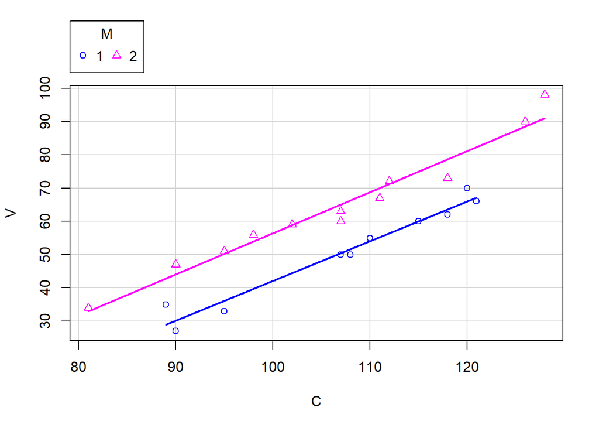

```r
dd$M<-as.factor(dd$M)

##############################################################################

# DESCRIPTIVA

scatterplot(V~C|M,smooth=F,data=dd)
```

```r
##############################################################################
```

**Plantegeu i ajusteu el model lineal factorial de la variable V en funció del factor M i de la covariable C.**

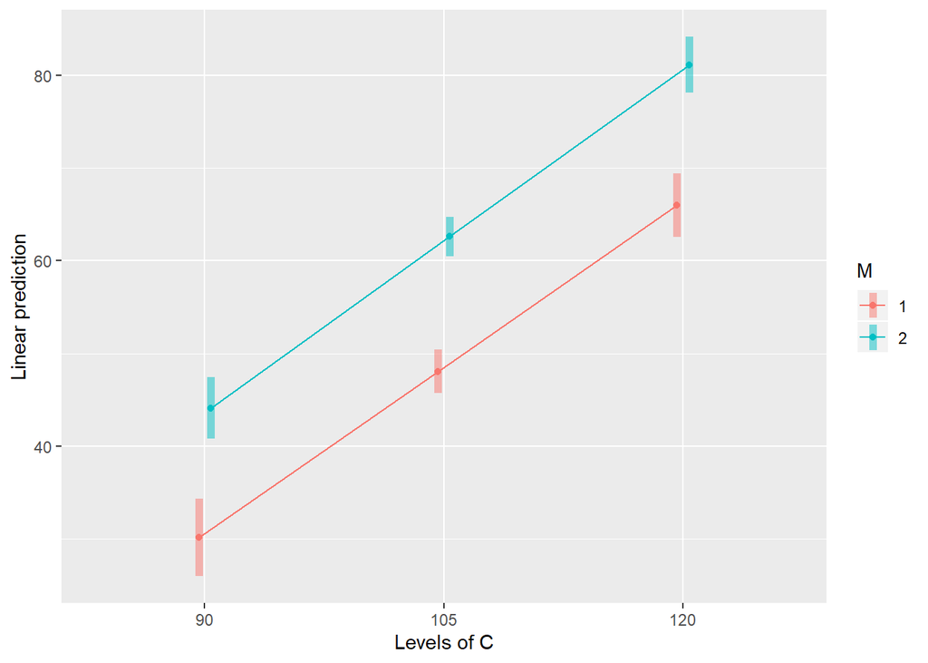

```r
m0<-lm(V~1,dd)
mv<-lm(V~M+C+M:C,dd)
#mv<-lm(V~M*C,dd)
emmip(mv,M~C,CIs=T,at=list(C=c(90,105,120)))
```

**Suposant que es compleixen les condicions dels models lineal, amb $\alpha=0.05$, estimeu els paràmetres i contrasteu els test de cada paràmetre (paràmetre=0, o no),**

```r
summary(mv)
```

```
##
## Call:
## lm(formula = V ~ M + C + M:C, data = dd)
##
## Residuals:
##     Min      1Q  Median      3Q     Max
## -5.6767 -1.9789  0.0376  1.3367  6.9744
##
## Coefficients:
##              Estimate Std. Error t value Pr(>|t|)
## (Intercept) -77.49366   10.33232  -7.500 6.07e-07 ***
## M2           10.45276   13.05628   0.801    0.434
## C             1.19565    0.09575  12.487 2.65e-10 ***
## M2:C          0.03924    0.12133   0.323    0.750
## ---
## Signif. codes:  0 '***' 0.001 '**' 0.01 '*' 0.05 '.' 0.1 ' ' 1
##
## Residual standard error: 3.474 on 18 degrees of freedom
## Multiple R-squared:  0.966,  Adjusted R-squared:  0.9603
## F-statistic: 170.4 on 3 and 18 DF,  p-value: 2.112e-13
```

** Tenen algun efecte C i M sobre V?**

```r
#Test omnibus
anova(m0,mv)
```

```
## Analysis of Variance Table
##
## Model 1: V ~ 1
## Model 2: V ~ M + C + M:C
##   Res.Df    RSS Df Sum of Sq      F    Pr(>F)
## 1     21 6385.8
## 2     18  217.2  3    6168.6 170.42 2.112e-13 ***
## ---
## Signif. codes:  0 '***' 0.001 '**' 0.01 '*' 0.05 '.' 0.1 ' ' 1
```

```r
# Tests anova
Anova(mv)
```

```
## Anova Table (Type II tests)
##
## Response: V
##           Sum Sq Df  F value    Pr(>F)
## M         1168.3  1  96.8287 1.144e-08 ***
## C         5192.8  1 430.3826 5.115e-14 ***
## M:C          1.3  1   0.1046    0.7501
## Residuals  217.2 18
## ---
## Signif. codes:  0 '***' 0.001 '**' 0.01 '*' 0.05 '.' 0.1 ' ' 1
```

**Es compleixen les condicions de ML? Hi ha valors estranys?**

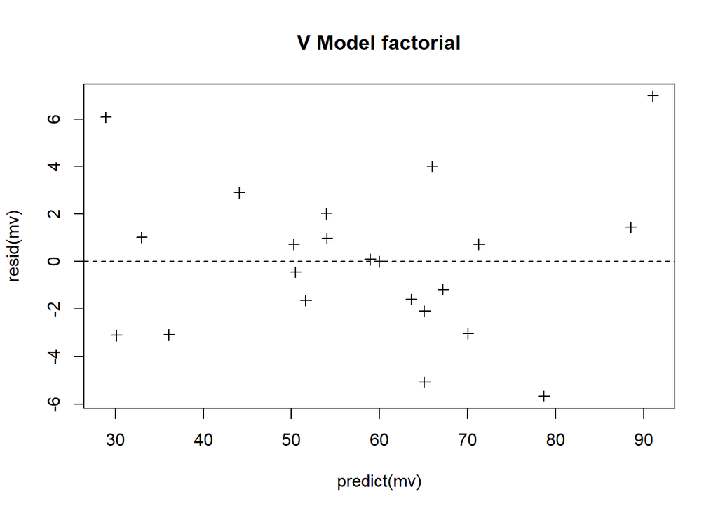

```r
# Diagnòstics
plot(predict(mv),resid(mv),pch=3,main="V Model factorial")
abline(h=0,lty=2)
```

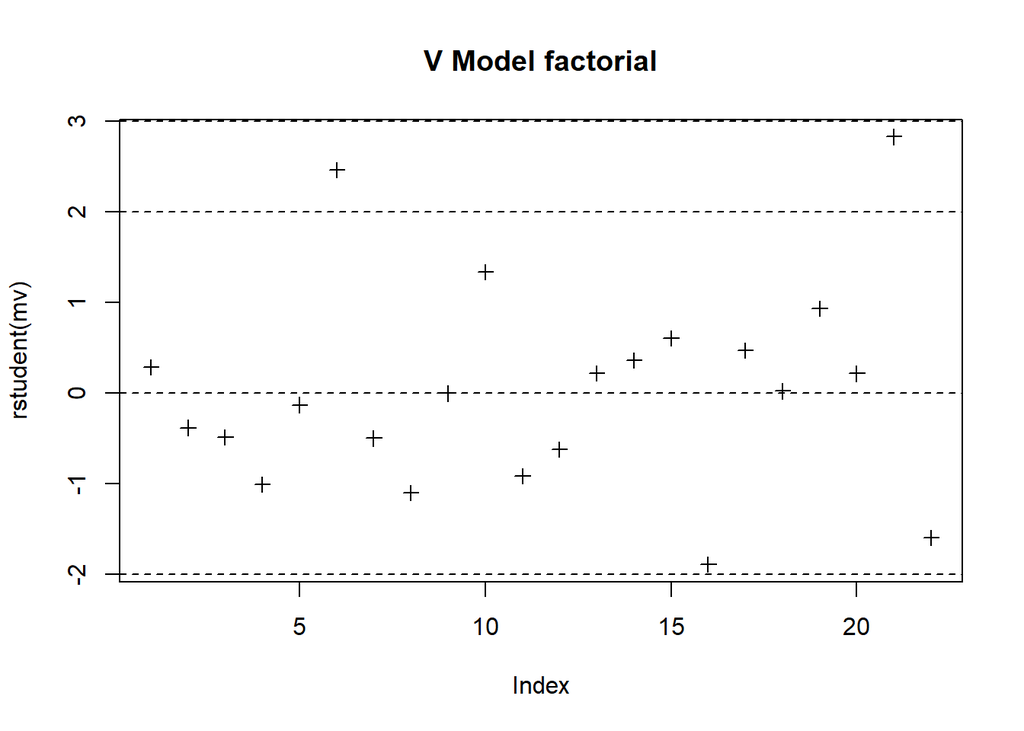

```r
#Valors estranys
plot(rstudent(mv),pch=3,main="V Model factorial")
abline(h=c(-3,-2,0,2,3),lty=2)
```

### Contrasteu també els test adequats per contestar les preguntes següents:

**a) Les dues rectes són iguals? o no?**

```r
# Iguals vs diferents
anova(lm(V~C,dd),mv)
```

```
## Analysis of Variance Table
##
## Model 1: V ~ C
## Model 2: V ~ M + C + M:C
##   Res.Df     RSS Df Sum of Sq      F    Pr(>F)
## 1     20 1386.74
## 2     18  217.18  2    1169.6 48.467 5.668e-08 ***
## ---
## Signif. codes:  0 '***' 0.001 '**' 0.01 '*' 0.05 '.' 0.1 ' ' 1
```

```r
# Iguals vs paral·leles diferente
anova(lm(V~C,dd),lm(V~C+M,dd))
```

```
## Analysis of Variance Table
##
## Model 1: V ~ C
## Model 2: V ~ C + M
##   Res.Df     RSS Df Sum of Sq      F    Pr(>F)
## 1     20 1386.74
## 2     19  218.44  1    1168.3 101.62 4.624e-09 ***
## ---
## Signif. codes:  0 '***' 0.001 '**' 0.01 '*' 0.05 '.' 0.1 ' ' 1
```

```r
# En algun punt prop del centre de les C, les E[V] són diferents?
pairs(emmeans(mv,~M|C))
```

```
## C = 107:
##  contrast estimate   SE df t.ratio p.value
##  1 - 2       -14.6 1.49 18 -9.834  <.0001
```

**b) Les dues rectes són paral·leles? o no?**

```r
anova(lm(V~M+C,dd),mv)
```

```
## Analysis of Variance Table
##
## Model 1: V ~ M + C
## Model 2: V ~ M + C + M:C
##   Res.Df    RSS Df Sum of Sq      F Pr(>F)
## 1     19 218.44
## 2     18 217.18  1     1.262 0.1046 0.7501
```

```r
Anova(mv)
```

```
## Anova Table (Type II tests)
##
## Response: V
##           Sum Sq Df  F value    Pr(>F)
## M         1168.3  1  96.8287 1.144e-08 ***
## C         5192.8  1 430.3826 5.115e-14 ***
## M:C          1.3  1   0.1046    0.7501
## Residuals  217.2 18
## ---
## Signif. codes:  0 '***' 0.001 '**' 0.01 '*' 0.05 '.' 0.1 ' ' 1
```

```r
# Separació dels pendents
(emmp<-emtrends(mv,~M,var="C"))
```

```
##  M C.trend     SE df lower.CL upper.CL
##  1    1.20 0.0957 18    0.994     1.40
##  2    1.23 0.0745 18    1.078     1.39
##
## Confidence level used: 0.95
```

```r
pairs(emmp)
```

```
##  contrast estimate    SE df t.ratio p.value
##  1 - 2     -0.0392 0.121 18 -0.323  0.7501
```

```r
#CLD(emmp)
```

**c) Les dues rectes tenen el mateix terme independent? o no?**

```r
anova(lm(V~C+M:C,dd),mv)
```

```
## Analysis of Variance Table
##
## Model 1: V ~ C + M:C
## Model 2: V ~ M + C + M:C
##   Res.Df    RSS Df Sum of Sq      F Pr(>F)
## 1     19 224.91
## 2     18 217.18  1    7.7334 0.6409 0.4338
```

```r
pairs(emmeans(mv,~M|C,at=list(C=0)))
```

```
## C = 0:
##  contrast estimate   SE df t.ratio p.value
##  1 - 2       -10.5 13.1 18 -0.801  0.4338
```

**d) Per cadascun dels següents valores de la variable C: 90, 105 i 120, quines diferències hi ha en la valoració segons el mètode?**

```r
(emm<-emmeans(mv,~M|C,at=list(C=c(90,105,120))))
```

```
## C =  90:
##  M emmean   SE df lower.CL upper.CL
##  1   30.1 1.99 18     25.9     34.3
##  2   44.1 1.57 18     40.8     47.4
##
## C = 105:
##  M emmean   SE df lower.CL upper.CL
##  1   48.0 1.12 18     45.7     50.4
##  2   62.6 1.01 18     60.5     64.7
##
## C = 120:
##  M emmean   SE df lower.CL upper.CL
##  1   66.0 1.64 18     62.5     69.4
##  2   81.1 1.43 18     78.1     84.2
##
## Confidence level used: 0.95
```

```r
pairs(emm)
```

```
## C =  90:
##  contrast estimate   SE df t.ratio p.value
##  1 - 2       -14.0 2.53 18 -5.518  <.0001
##
## C = 105:
##  contrast estimate   SE df t.ratio p.value
##  1 - 2       -14.6 1.51 18 -9.674  <.0001
##
## C = 120:
##  contrast estimate   SE df t.ratio p.value
##  1 - 2       -15.2 2.18 18 -6.963  <.0001
```

```r
#CLD(emm)
```

**e) En cas de poder simplificar el model, torneu a respondre les preguntes c) i d)**

*Podem simplificar traient la interacció.*

**Estimeu els paràmetres i contrasteu els test de cada paràmetre (paràmetre=0, o no), Tenen algun efecte C i M sobre V?**

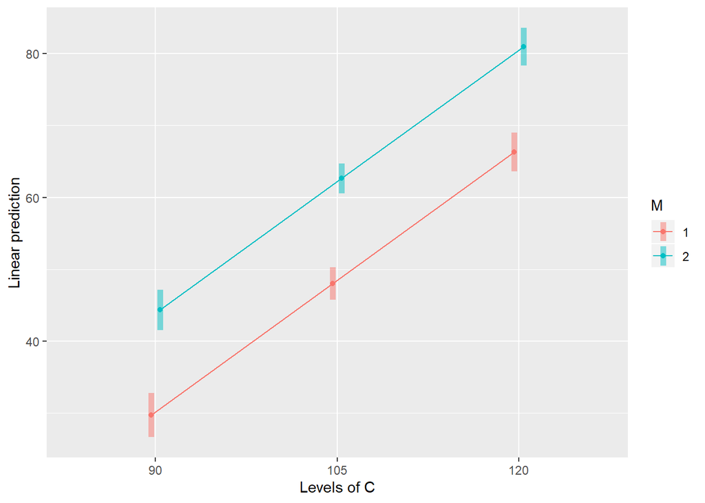

```r
# e) traient la inreracció per simplificar el model

mv2<-lm(V~M+C,dd)
emmip(mv2,M~C,CIs=T,at=list(C=c(90,105,120)))
```

```r
summary(mv2)
```

```
##
## Call:
## lm(formula = V ~ M + C, data = dd)
##
## Residuals:
##    Min     1Q Median     3Q    Max
## -5.503 -2.025 -0.088  1.529  7.296
##
## Coefficients:
##              Estimate Std. Error t value Pr(>|t|)
## (Intercept) -80.11563    6.25264  -12.81 8.50e-11 ***
## M2           14.64776    1.45307   10.08 4.62e-09 ***
## C             1.22009    0.05741   21.25 1.05e-14 ***
## ---
## Signif. codes:  0 '***' 0.001 '**' 0.01 '*' 0.05 '.' 0.1 ' ' 1
##
## Residual standard error: 3.391 on 19 degrees of freedom
## Multiple R-squared:  0.9658, Adjusted R-squared:  0.9622
## F-statistic: 268.2 on 2 and 19 DF,  p-value: 1.186e-14
```

```r
anova(m0,mv2)
```

```
## Analysis of Variance Table
##
## Model 1: V ~ 1
## Model 2: V ~ M + C
##   Res.Df    RSS Df Sum of Sq      F    Pr(>F)
## 1     21 6385.8
## 2     19  218.4  2    6167.4 268.22 1.186e-14 ***
## ---
## Signif. codes:  0 '***' 0.001 '**' 0.01 '*' 0.05 '.' 0.1 ' ' 1
```

```r
Anova(mv2)
```

```
## Anova Table (Type II tests)
##
## Response: V
##           Sum Sq Df F value    Pr(>F)
## M         1168.3  1  101.62 4.624e-09 ***
## C         5192.8  1  451.67 1.053e-14 ***
## Residuals  218.4 19
## ---
## Signif. codes:  0 '***' 0.001 '**' 0.01 '*' 0.05 '.' 0.1 ' ' 1
```

**Es compleixen les condiciond de ML? Hi ha valors estranys?**

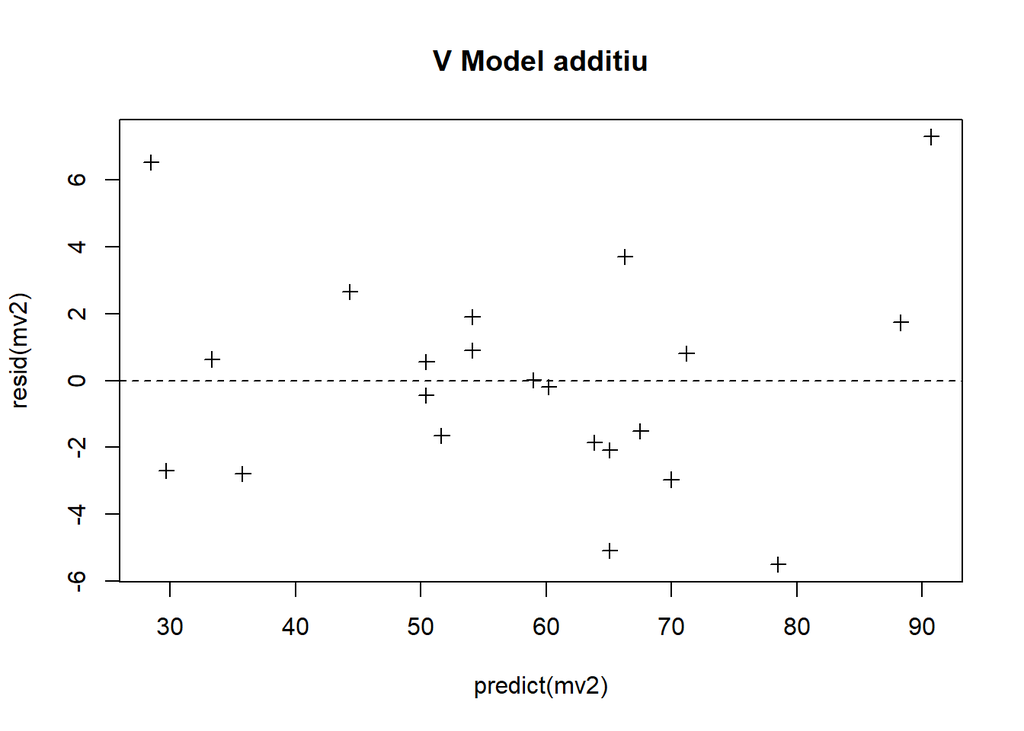

```r
plot(predict(mv2),resid(mv2),pch=3,main="V Model additiu")
abline(h=0,lty=2)
```

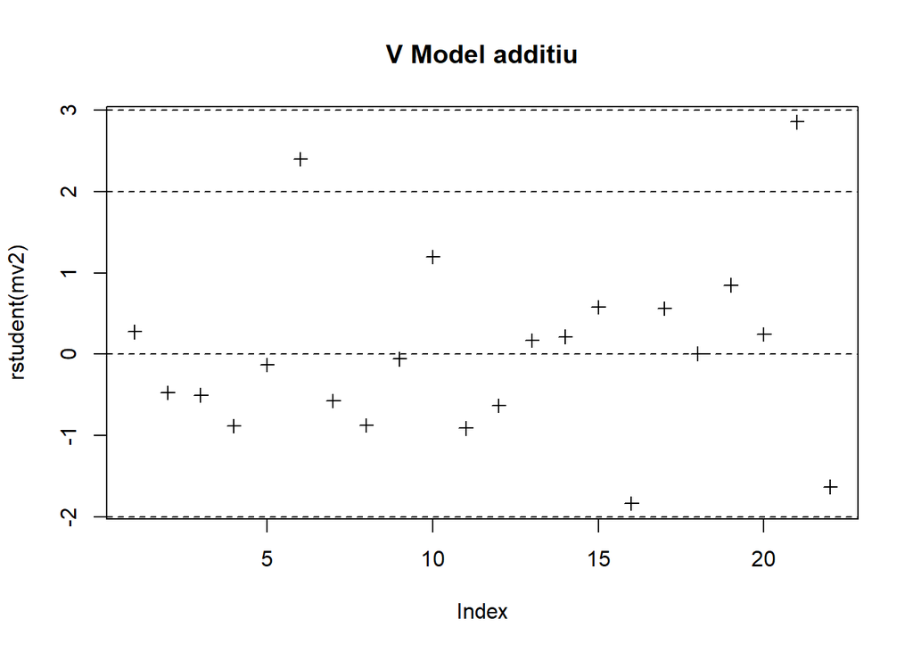

```r
plot(rstudent(mv2),pch=3,main="V Model additiu")
abline(h=c(-3,-2,0,2,3),lty=2)
```

```r
# mes guai fer abline(h=c(-3,-1.96,0,1.96,3),lty=2)
# perque normal i merdes
```

**c) Les dues rectes tenen el mateix terme independent? o no?**

```r
# Resposta a c)
anova(lm(V~C,dd),mv2)
```

```
## Analysis of Variance Table
##
## Model 1: V ~ C
## Model 2: V ~ M + C
##   Res.Df     RSS Df Sum of Sq      F    Pr(>F)
## 1     20 1386.74
## 2     19  218.44  1    1168.3 101.62 4.624e-09 ***
## ---
## Signif. codes:  0 '***' 0.001 '**' 0.01 '*' 0.05 '.' 0.1 ' ' 1
```

**d) Per cadascun dels següents valors de la variable C: 90, 105 i 120, quines diferències hi ha en la valoració segons el mètode?**

```r
# Resposta a d)
(emm2<-emmeans(mv2,~M|C,at=list(C=c(90,105,120))))
```

```
## C =  90:
##  M emmean    SE df lower.CL upper.CL
##  1   29.7 1.462 19     26.6     32.8
##  2   44.3 1.352 19     41.5     47.2
##
## C = 105:
##  M emmean    SE df lower.CL upper.CL
##  1   48.0 1.080 19     45.7     50.3
##  2   62.6 0.981 19     60.6     64.7
##
## C = 120:
##  M emmean    SE df lower.CL upper.CL
##  1   66.3 1.297 19     63.6     69.0
##  2   80.9 1.257 19     78.3     83.6
##
## Confidence level used: 0.95
```

```r
pairs(emm2)
```

```
## C =  90:
##  contrast estimate   SE df t.ratio p.value
##  1 - 2       -14.6 1.45 19 -10.081 <.0001
##
## C = 105:
##  contrast estimate   SE df t.ratio p.value
##  1 - 2       -14.6 1.45 19 -10.081 <.0001
##
## C = 120:
##  contrast estimate   SE df t.ratio p.value
##  1 - 2       -14.6 1.45 19 -10.081 <.0001
```

```r
#CLD(emm2)
```

##============================================================================= ## Repetiu l’exercici, però amb les valoracions de la variable VV.

*Descriptiva*

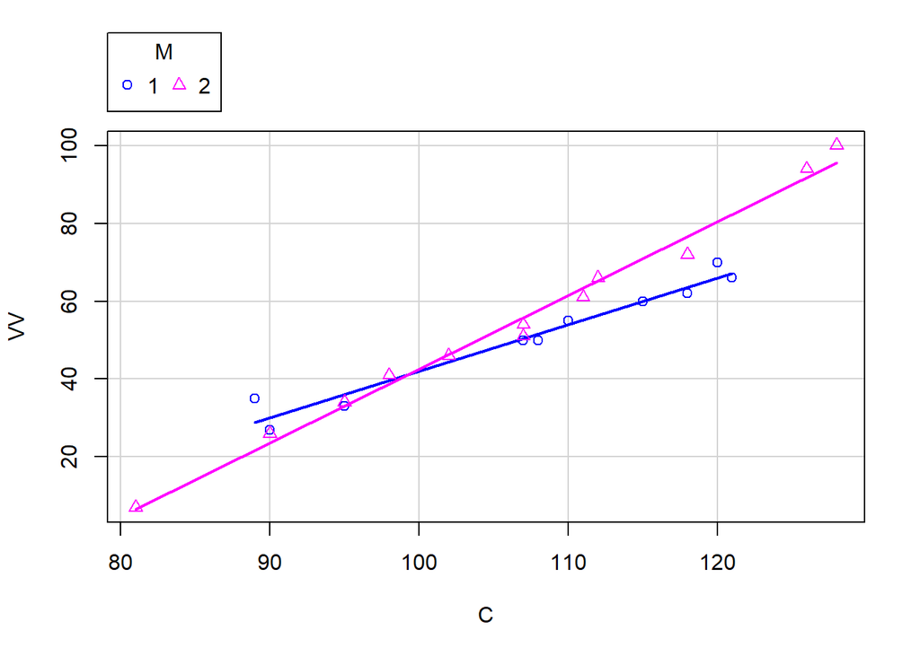

```r
scatterplot(VV~C|M,smooth=F,data=dd)
```

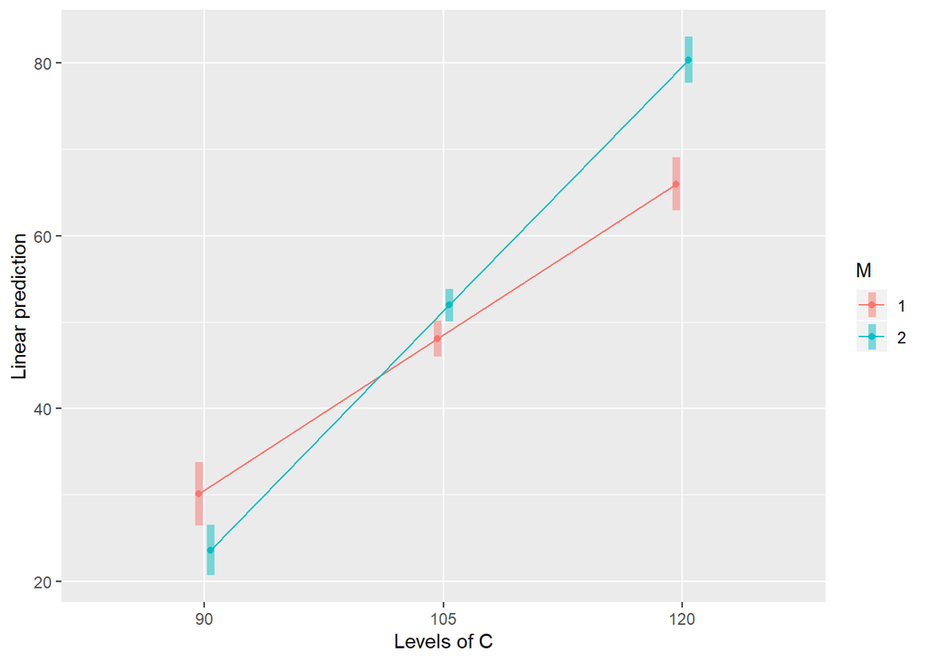

```r
m0<-lm(VV~1,dd)
mvv<-lm(VV~M+C+M:C,dd)
#mvv<-lm(VV~M*C,dd)
emmip(mvv,M~C,CIs=T,at=list(C=c(90,105,120)))
```

**Estimeu els paràmetres i contrasteu els test de cada paràmetre (paràmetre=0, o no), Tenen algun efecte C i M sobre VV?**

```r
summary(mvv)
```

```
##
## Call:
## lm(formula = VV ~ M + C + M:C, data = dd)
##
## Residuals:
##     Min      1Q  Median      3Q     Max
## -4.7524 -1.7235 -0.1493  1.9500  6.0805
##
## Coefficients:
##              Estimate Std. Error t value Pr(>|t|)
## (Intercept) -77.49366    9.15403  -8.466 1.09e-07 ***
## M2          -69.20305   11.56736  -5.983 1.17e-05 ***
## C             1.19565    0.08483  14.095 3.64e-11 ***
## M2:C          0.69639    0.10750   6.478 4.30e-06 ***
## ---
## Signif. codes:  0 '***' 0.001 '**' 0.01 '*' 0.05 '.' 0.1 ' ' 1
##
## Residual standard error: 3.077 on 18 degrees of freedom
## Multiple R-squared:  0.9828, Adjusted R-squared:  0.9799
## F-statistic: 342.3 on 3 and 18 DF,  p-value: 4.669e-16
```

```r
#Test omnibus
anova(m0,mvv)
```

```
## Analysis of Variance Table
##
## Model 1: VV ~ 1
## Model 2: VV ~ M + C + M:C
##   Res.Df    RSS Df Sum of Sq      F    Pr(>F)
## 1     21 9896.4
## 2     18  170.5  3    9725.9 342.32 4.669e-16 ***
## ---
## Signif. codes:  0 '***' 0.001 '**' 0.01 '*' 0.05 '.' 0.1 ' ' 1
```

```r
# Tests anova
Anova(mvv)
```

```
## Anova Table (Type II tests)
##
## Response: VV
##           Sum Sq Df F value    Pr(>F)
## M          149.7  1  15.812 0.0008852 ***
## C         9260.3  1 977.798 < 2.2e-16 ***
## M:C        397.5  1  41.967 4.296e-06 ***
## Residuals  170.5 18
## ---
## Signif. codes:  0 '***' 0.001 '**' 0.01 '*' 0.05 '.' 0.1 ' ' 1
```

**Es compleixen les condiciond de ML? Hi ha valors estranys?**

## Utilitzem el model factorial per haver-hi interacció

**a) Les dues rectes són iguals? o no?.**

**b) Les dues rectes són paral·leles? o no?**

**c) Les dues rectes tenen el mateix terme independent? o no?**

**d) Per cadascun dels següents valores de la variable c: 90, 105 i 120, quines diferències hi ha en la valoració segons el mètode?**

**e) En cas de poder simplificar el model, torneu a respondre les preguntes c) i d).**